# MD8-9

2023-11-21

```r
library(tidyverse)
library(moderndive)
library(infer)
```

## Question1

```r
set.seed(1108)

poll <- tibble(
  vote_gop = rbinom(n = 1000,
                    size = 1,
                    prob = .53))
```

```r
n_bootstrap_samples <- 1000

bootstrap_dist <-
  rep_sample_n(poll,
               size = nrow(poll),
               reps = n_bootstrap_samples,
               replace = TRUE) %>%
  group_by(replicate) %>%
  summarize(bootstrap_mean = mean(vote_gop))

confidence_interval <- quantile(bootstrap_dist$bootstrap_mean, c(0.025, 0.975))

confidence_interval
```

```
##     2.5%    97.5%
## 0.483975 0.547025
```

second method:

```r
set.seed(1108)

bootstrap_interval_infer <-
  poll %>%
  specify(response = vote_gop) %>%
  generate(reps = 1000, type = "bootstrap") %>%
  calculate(stat = "mean") %>%
  get_ci(level = 0.95)

bootstrap_interval_infer
```

```
## # A tibble: 1 × 2
##   lower_ci upper_ci
##      <dbl>    <dbl>
## 1    0.484    0.548
```

The two confidence intervals are pretty similar, but not exact the same. The process of bootstrap re sampling could result in slightly difference in the confidence intervals due to its inherent randomness.

## Question2

```r
rap_poll <- read_csv("https://raw.githubusercontent.com/rfordatascience/tidytuesday/master/data/2020/2020-04-14/polls.csv")%>%
  filter(rank == 1)
rap_poll
```

```
## # A tibble: 107 × 9
##     rank title        artist gender  year critic_name critic_rols critic_country
##    <dbl> <chr>        <chr>  <chr>  <dbl> <chr>       <chr>       <chr>
##  1     1 Terminator … Publi… male    1998 Joseph Aba… Fat Beats   US
##  2     1 Players      Slum … male    1997 Biba Adams  Critic      US
##  3     1 Rapper’s De… Sugar… male    1979 Dart Adams  Critic      US
##  4     1 Juicy        The N… male    1994 Insanul Ah… Genius      US
##  5     1 In Da Club   50 Ce… male    2003 Joey Akan   Critic      Nigeria
##  6     1 The Message  Grand… male    1982 Antonio ‘R… Critic      US
##  7     1 Fight The P… Publi… male    1989 Ivie Ani    Critic      US
##  8     1 Nuthin’ But… Dr Dr… male    1992 Andrew Bar… Fake Shore… US
##  9     1 The Message  Grand… male    1982 Fionn Birr  Critic      Germany
## 10     1 We Got It F… Clipse male    2006 Davide Bor… Critic      Germany
## # ℹ 97 more rows
## # ℹ 1 more variable: critic_country2 <chr>
```

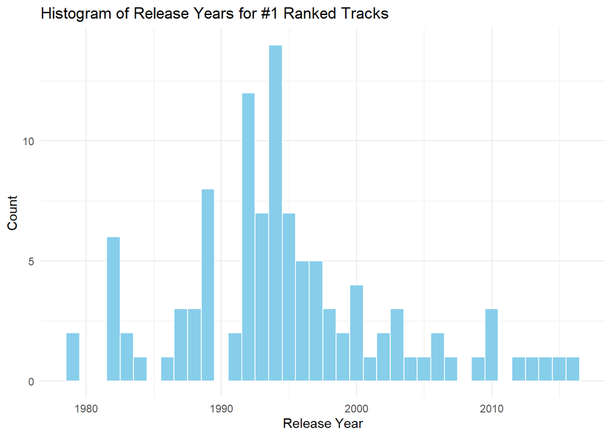

```r
library(ggplot2)

ggplot(data = rap_poll,
       mapping = aes(x = year)) +
  geom_histogram(binwidth = 1, fill = "skyblue", color = "white") +
  labs(title = "Histogram of Release Years for #1 Ranked Tracks",
       x = "Release Year",
       y = "Count")+
  theme_minimal()
```

The year of the most commonly named favorite track was 1994, with 14 critics naming a track.

## Question3

```r
set.seed(7)

bootstrap_rap <- rap_poll |>
  rep_sample_n(size = 107, reps = 1000, replace = TRUE) |>
  group_by(replicate) |>
  summarize(mean_year = mean(year))

quantile(bootstrap_rap$mean_year, c(0.025, 0.975))
```

```
##     2.5%    97.5%
## 1993.495 1996.402
```

## Question4

```r
set.seed(7)

bootstrap_rap_2 <- rap_poll |>
  rep_sample_n(size = 25, reps = 1000, replace = TRUE) |>
  group_by(replicate) |>
  summarize(mean_year = mean(year))
quantile(bootstrap_rap_2$mean_year, c(0.025, 0.975))
```

```
##     2.5%    97.5%
## 1991.958 1997.961
```

# Chapter9

```r
pl_data <- read_csv("https://raw.githubusercontent.com/vaiseys/dav-course/main/Data/premier_league.csv")
glimpse(pl_data)
```

```
## Rows: 380
## Columns: 4
## $ home_team  <chr> "Bournemouth", "Chelsea", "Everton", "Leicester", "Man Unit…
## $ away_team  <chr> "Aston Villa", "Swansea", "Watford", "Sunderland", "Tottenh…
## $ score_diff <dbl> -1, 0, 0, 2, 1, -2, -2, 0, -1, -3, -1, -3, -2, 2, 0, 0, -1,…
## $ result     <chr> "aw", "d", "d", "hw", "hw", "aw", "aw", "d", "aw", "aw", "a…
```

## Question5

```r
hw_prop <- pl_data |>
  filter(result == "hw") |>
  summarize(prop_hw = n() / nrow(pl_data))
hw_prop
```

```
## # A tibble: 1 × 1
##   prop_hw
##     <dbl>
## 1   0.413
```

The proportion of hw(home wins) is about 41.32%.

## Question6

```r
set.seed(22)

sampled_proportions <- c()

for (i in 1:1000) {

  sampled_results <- sample(c("aw", "hw" , "d"),
                            size = 380,
                            replace = TRUE,
                            prob = c(1/3,1/3,1/3))
  prop <- sum(sampled_results == "hw")/380
  sampled_proportions[i] <- prop

}
prop_hw <- data.frame(Proportions = sampled_proportions)
```

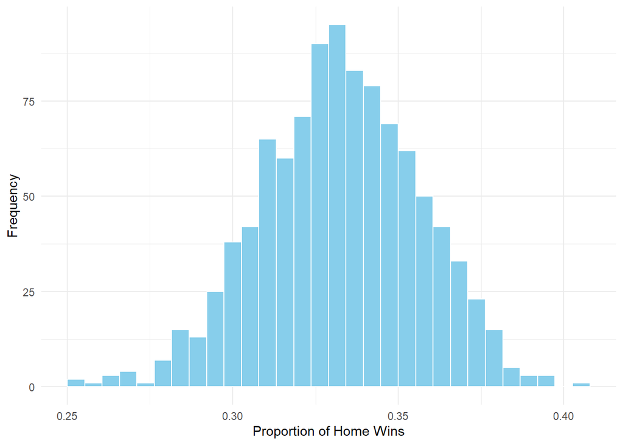

```r
prop_hw |>
  ggplot(aes(x = Proportions)) +
  geom_histogram(fill = "skyblue", color = "white") +
  labs(x = "Proportion of Home Wins",
       y = "Frequency")+
  theme_minimal()
```

The histogram shows a normal distribution around 0.33, lower than the proportion of hw in the previous question. It suggests that the home wins is more frequent given that each result is equally likely.

## Question7 & 8

A null hypothesis is that the proportion of home wins is equal to the proportion of other results. If the home wins and away teams win is at the same proportion it is a null hypothesis. The alternative hypothesis would be that the proportion of home wins is different to other results.

The p-value is the probability that the proportion of home wins is just as or more extreme than the proportion of home wins when we assume all three possible results (home wins, away wins, and draws) are equally probable.